# Paris-Dakar : analyse de l’enquête EuroBrodMap 2009

Exercice pédagogiques de statistiques et cartographie

Auteur·rice

Claude Grasland, Mamadou Bouna Timera, Labaly Toure

Date de publication

2026-03-11

## Introduction

Les archives du projet EuroBroadMap n’ont pas fait l’objet d’un dépôt en bonne dûe forme à la fin du projet et différentes versions de la base de données corrigée ont circulé avant qu’une version stabilisée ne soit finalement arrêtée tardivement. C’est la raison pour laquelle il est important de repartir de cette dernière version et de la tranformer en un fichier stabilisé une bonne fois pour toutes … 15 ans après !

L’enquête avait été réalisée sur format papier sous la forme d’une feuille A3 recto-verso pliée. Chaque enquêteur l’avait ensuite traduit dans la langue de son pays et adapté dans lé détail. Une première phase de test du questionnaire avait permis d’harmoniser au maximum les questions et de s’assurer qu’elles pourraient être posées dans tous les pays dans les mêmes termes.

En dehors des métadonnées enregistrées par l’enquêteur (lieu et date d’enquête, niveau et cursus des étudiants interrogés), toutes les informations ont été recueillies à partir du questionnaire que remplissaient les étudiants d’une même salle de cours. La durée moyenne de réponse était de 15 à 30 minutes.

# 1. Données de cadrage et expérience du monde

La première partie du questionnaire apportait des données de cadrage sur les individus (âge, sexe) mais aussi sur leurs mobilités personnelles et celle de leurs ascendants. On a ainsi pu évaluer l’expérience plus ou moins grande qu’ont les étudiants de l’étranger, des autres pays et des autres langues. Une question portait plus directement sur le niveau d’échelle auquel les étudiants ont le sentiment d’appartenir, du local au global. Mais on verra par la suite que son interprétation s’est avérée difficile.

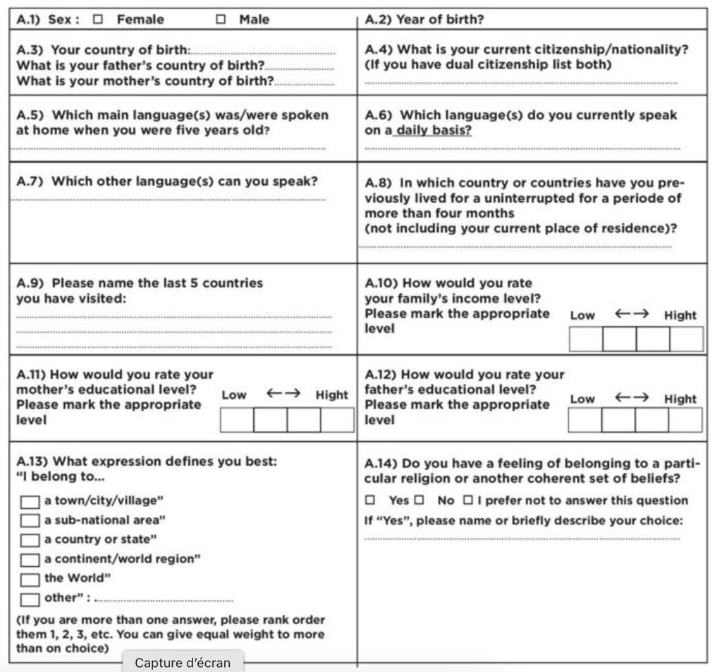

EuroBroadmap 2010, partie 1

**Télécharger le jeu de données n°1**

- [Données d’enquête au format .xlsx](https://github.com/worldregio/altermap/raw/refs/heads/main/data/parisdakar/ebmsurvey2009.xlsx)
- [Données d’enquête au format .RDS](https://github.com/worldregio/altermap/raw/refs/heads/main/data/parisdakar/ebmsurvey2009.RDS)

La feuille data comporte 479 lignes, chacune correspondant aux réponses d’un étudiant français ou sénégalais. L’anaonymat des étudiants est préservé grâce à un code unique.

| id | date | cit | sta | stu | sex | age | nai | nat | lan | nblan | nbmig | nbvis | inc | lev | rel | rel_name | stalik1 | stalik2 | stalik3 | staunl1 | staunl2 | staunl3 |
| --- | --- | --- | --- | --- | --- | --- | --- | --- | --- | --- | --- | --- | --- | --- | --- | --- | --- | --- | --- | --- | --- | --- |
| FRA-PAR-ART-001 | 2009 | Paris | France | ART | F | 20 | FRA | FRA | French | 3 | 0 | 5 | 2 | Global | No or Refused | NA | HRV | DEU | ITA | X-AMR | AUS | JPN |
| FRA-PAR-ART-002 | 2009 | Paris | France | ART | M | 24 | ITA | ITA | Italian | 3 | 1 | 5 | 4 | Supranational | No or Refused | NA | BRA | CAN | NOR | CHN | HTI | AGO |
| FRA-PAR-ART-003 | 2009 | Paris | France | ART | F | 21 | FRA | FRA | French | 3 | 0 | 5 | 6 | Local | No or Refused | NA | ITA | ESP | CAN | IRQ | PAK | IND |
| FRA-PAR-ART-004 | 2009 | Paris | France | ART | F | 21 | FRA | FRA | French | 3 | 1 | 4 | 4 | National | No or Refused | NA | USA | ESP | DEU | CHN | CHE | JPN |
| FRA-PAR-ART-005 | 2009 | Paris | France | ART | F | 21 | FRA | FRA | French | 3 | 0 | 1 | 4 | Local | No or Refused | NA | CAN | IRL | FIN | USA | BRA | AUS |
| FRA-PAR-ART-006 | 2009 | Paris | France | ART | M | 19 | FRA | FRA | French | 4 | 0 | 3 | 4 | Global | No or Refused | NA | DEU | CAN | NA | USA | GBR | CHE |

La définition des variables retenues est présentée dans la feuille de métadonnées en français et en anglais. On se limite ici à l’affichage en français :

[output not shown]

Enfin le dernier onglet de la feuille excel présente la source et indique la citation du projet et des auteurs de l’enquête.

| (c) Enquête EuroBroadMap 2009 - M.B. Timera (Sénégal) - C. Grasland et C. Didelon (France) |
| --- |
| https://worldregio.github.io/eurobroadmap/ |

## 1.1 Echantillonage

### Nombre de réponses

```
        n     %
Dakar 208  43.4
Paris 271  56.6
Total 479 100.0
```

Il y a eu 208 réponses à Dakar et 271 à Paris. L’objectif de 240 réponses par ville n’a donc pas été tout à fait atteint à Dakar et légèrement dépassé à Paris.

### Domaines d’étude

Les étudiants devaient être échantillonés dans six domaines d’étude : art et littérarure (ART), économie et gestion (BUS), sciences de l’ingénieur, mathématiques, physique et biologie (ENG), santé, pharmaie et médecine (HEA), sciences politiques et droit (POP), sciences humaines et sociales (SHS). On dispose de cette variable que pour l’échantillon des étudiants de Paris où les quotas semblent assez équilbrés

```
        n     %
ART    37  13.7
BUS    56  20.7
ENG    33  12.2
HEA    60  22.1
POL    36  13.3
SHS    49  18.1
Total 271 100.0
```

Dans le cas de Dakar,on ignore si les quotas ont été respectés car le champs idenifiant les dommaines d’étude n’a pas été enregistré.

### Sexe

```
        Femmes Hommes Total
  Dakar  22.2   77.8  100.0
  Paris  55.0   45.0  100.0
  All    40.9   59.1  100.0
```

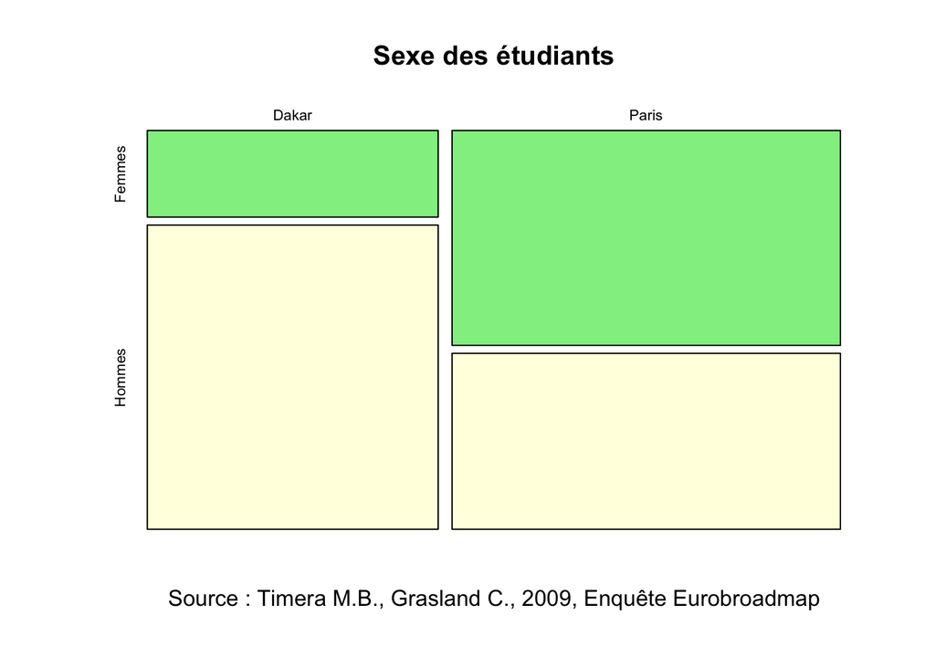

L’échantillon de Dakar comporte une nette majorité d’hommes. Celui de Paris une légère majorité de femmes. Dans le cas français, il existe peu de variations du sex-ratio par discipline, même si les femmes sont plus nombreuses dans les domaines artisitiques et moins nombreuses en économie-gestion et sciences de l’ingénieur.

```
         ART   BUS   ENG   HEA   POL   SHS   All
  Femmes  78.4  44.6  45.5  58.3  50.0  55.1  55.0
  Hommes  21.6  55.4  54.5  41.7  50.0  44.9  45.0
  Total  100.0 100.0 100.0 100.0 100.0 100.0 100.0
```

### Âge

La consigne étant de cibler si possible des étudiants de 3e année d’universitaire, on pouvait s’attendre à un âge modal d’environ 20 ans. or, si tel est bien le cas à Paris, il n’en va pas de même à Dakar où la majorité des étudiants enquêtés avaient plutôt de 26 à 30 ans.

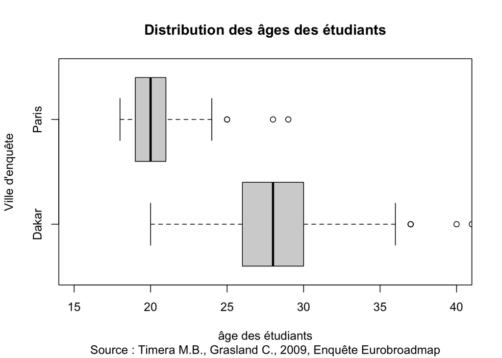

En dehors des variables utilisées pour définir l’échantillon, quelques variables de cadrage ont été retenus pour analyser les résultats aux questions constituant le coeur du questionnaire.

## 1.2 variables de cadrage

### Niveau économique familial

L’autoévaluation du niveau économique a été faite sur une échelle graphique comportant quatre cases. Mais les étudiants ont souvent coché des cases situées sur les lignes séparant les cases, ce qui aboutissait à 9 réponses possibles au lieu de 4. Nous avons procédé à un regroupement pour revenir à 4 niveaux en prenant par défaut le niveau le plus pas en cas d’ambiguïté. On obtient les résultats suivants pour les deux pays :

```
  0   2   3   4   5   6   7   8
 13  75   4 119  39 170   8  51
```

```
        1 très bas 2.bas 3.haut 4.très haut Total
  Dakar  37.0       31.2  29.3    2.4       100.0
  Paris   4.1       21.4  54.6   19.9       100.0
  All    18.4       25.7  43.6   12.3       100.0
```

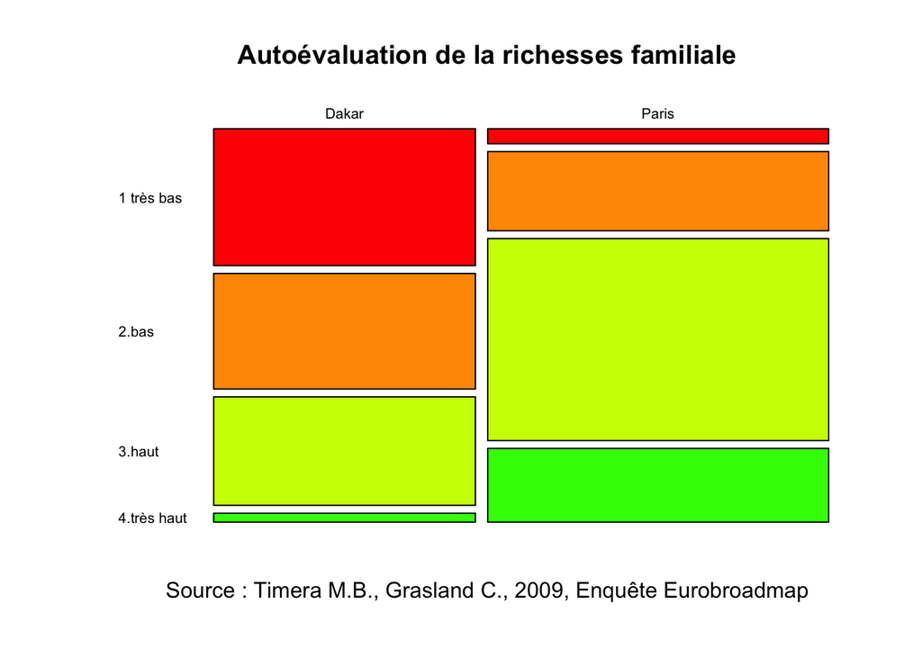

On constate - sans surprise - que l’autoévaluation de leur niveau économique par les étudiants est différente dans les deux pays et sensiblement plus élevé dans le cas des étudiants français.

### Langues parlées

#### Langue maternelle

Nous avons tout d’abord examine les langues maternelles déclarées par les étudiants à l’aide de la question relative à la langue principale parlée à l’âge de cinq ans. Les résultats des deux pays sont très différents.

Langues maternelles des étudiants sénégalais

| rang | Langue | nb. réponses | % |
| --- | --- | --- | --- |
| 1 | Wolof | 80 | 39.2 |
| 2 | Serer | 40 | 19.6 |
| 3 | Jola / Diola | 32 | 15.7 |
| 4 | Fulah | 17 | 8.3 |
| 5 | Other | 11 | 5.4 |
| 6 | French | 8 | 3.9 |
| 8 | Balante | 5 | 2.5 |
| 8 | Mandingue | 5 | 2.5 |
| 9 | Mandinka | 3 | 1.5 |
| 11 | Bambara | 1 | 0.5 |
| 11 | Kinyarwanda | 1 | 0.5 |
| 11 | Mbo | 1 | 0.5 |

Langues maternelles des étudiants français

| rang | Langue | nb. réponses | % |
| --- | --- | --- | --- |
| 1 | French | 235 | 87.0 |
| 2 | Arabic | 8 | 3.0 |
| 3 | English | 6 | 2.2 |
| 4 | Other | 4 | 1.5 |
| 5 | Spanish; Castilian | 3 | 1.1 |
| 8 | Chinese | 2 | 0.7 |
| 8 | Kabyle | 2 | 0.7 |
| 8 | Rundi | 2 | 0.7 |
| 8 | Tamil | 2 | 0.7 |
| 12 | German | 1 | 0.4 |
| 12 | Italian | 1 | 0.4 |
| 12 | Norwegian | 1 | 0.4 |
| 12 | Polish | 1 | 0.4 |
| 12 | Romanian | 1 | 0.4 |
| 12 | Urdu | 1 | 0.4 |

#### Diversité linguistique

En totalisant l’ensemble des langues que l’étudiant connaît ou a pratiqué depuis son enfance, on obtient une mesure de la diversité de son univers linguistique.

```
        1     2     3     4+    Total
  Dakar   1.0  17.8  33.7  47.6 100.0
  Paris   4.1  24.8  55.6  15.6 100.0
  All     2.7  21.8  46.0  29.5 100.0
```

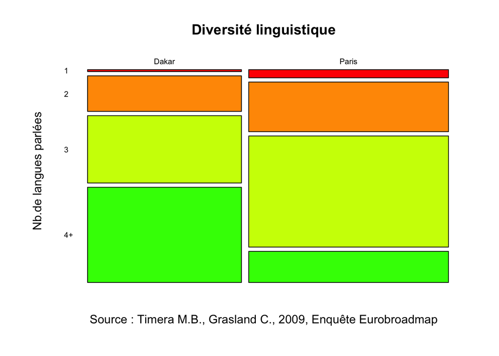

### Mobilité internationale

#### Migrations

```
        0     1     2     3     Total
  Dakar  86.5  12.0   1.4   0.0 100.0
  Paris  84.5  14.0   1.1   0.4 100.0
  All    85.4  13.2   1.3   0.2 100.0
```

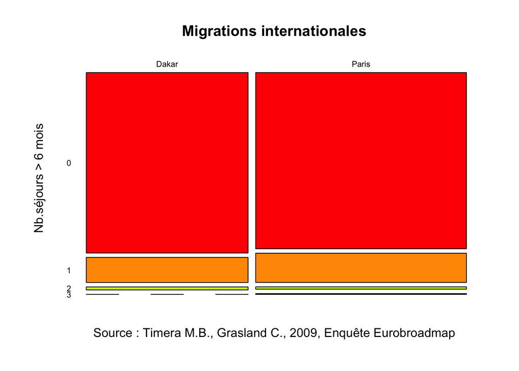

Il n’existe pas de différences significatives entre les étudianst français et sénégalais pour le critère des séjours de plus de six mois à l’étranger. Dans les deux cas, la très grande majorité des étudiants (84 à 87%) n’a pas effectué de séjour de plus de six mois dans un autre pays.

#### Mobilités

```
        0     1     2     3     4     5     Total
  Dakar  68.8  15.9   7.7   3.8   1.0   2.9 100.0
  Paris   1.5   3.3   5.2   7.0  17.3  65.7 100.0
  All    30.7   8.8   6.3   5.6  10.2  38.4 100.0
```

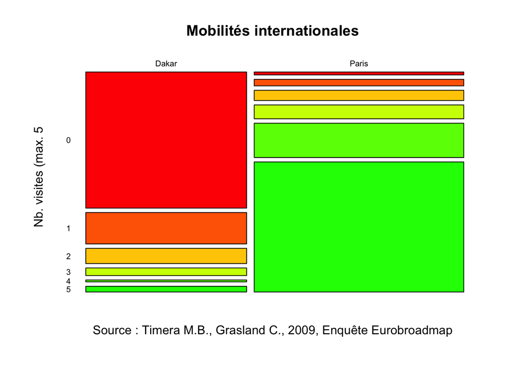

On trouve en revanche une différence entre les deux pays dans le cas des séjours de courte durée. La majorité des étudiants français ont cité le maximum de pays proposé dans la réponse alors qu’à l’inverse la majorité des étudiants sénégalais n’en ont coté aucun

### Religion

Cette question délicate a été posée en deux temps dans le questionnaire EuroBroadMap en demandant d’abord aux étudiants s’ils avaient une religion ou une croyance de type religieux. Puis en leur faisant préciser celle-ci s’ils en étaient d’accord. On notera qu’on a regroupé les non réponses et les refus de répondre avec la déclaration d’absence de pratique religieuse.

#### Croyance religieuse

```
        Non ou refus Oui   Total
  Dakar  12.5         87.5 100.0
  Paris  64.2         35.8 100.0
  All    41.8         58.2 100.0
```

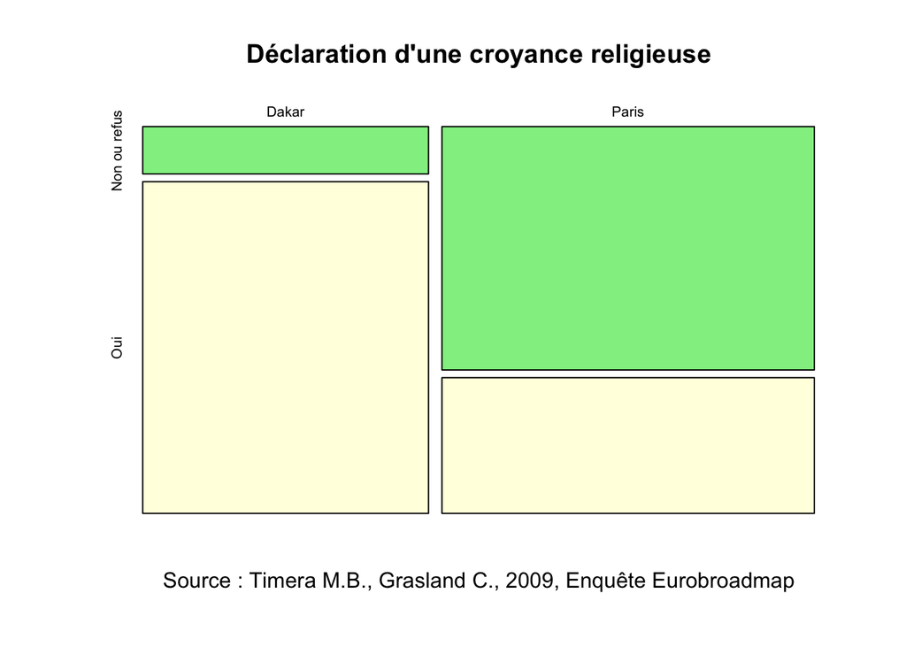

Seuls 36% des étudiants français ont déclaré une croyance religieuse contre 88% des étudiants sénégalais. Même si cette question ne recoupe pas exactement la pratique elle témoigne d’une différence fondamentale entre les deux échantillons observés.

#### Religions déclarées

Religions décalérées des étudiants sénégalais

| rang | Langue | nb. réponses | % |
| --- | --- | --- | --- |
| 1 | Muslim | 139 | 76.4 |
| 2 | Christian | 23 | 12.6 |
| 3 | Catholic | 15 | 8.2 |
| 4 | NA | 2 | 1.1 |
| 6 | No answer | 1 | 0.5 |
| 6 | Other | 1 | 0.5 |
| 6 | Traditional | 1 | 0.5 |

Dans le cas du Sénégal, les étudiants qui ont déclaré une religion ont opté à 76% pour la religion musulmane et à 21% pour la religion chrétienne (en général) ou catholique (en particulier).

Religions décalérées des étudiants français

| rang | Langue | nb. réponses | % |
| --- | --- | --- | --- |
| 1 | Catholic | 48 | 49.5 |
| 2 | Christian | 22 | 22.7 |
| 3 | Muslim | 10 | 10.3 |
| 4 | Jewish | 7 | 7.2 |
| 5 | Other | 5 | 5.2 |
| 6 | Protestant | 3 | 3.1 |
| 8 | Orthodox | 1 | 1.0 |
| 8 | NA | 1 | 1.0 |

Dans le cas français on trouve beaucoup moins de réponses (la plupart des étudiants n’ayant pas déclaré de sentiment religieux) avec une majorité de catholiques (50%) ou chrétiens (23%) mais aussi musulmans (10%) ou juifs (7%).

## 1.3 Echelles d’appartenance territoriale

La questions n’a sans doute pas été posée de la façon la plus satisfaisante mais on peut néanmoins en tirer quelques enseignements. On se limitera ici à l’analyse de la réponse fournie en premier, tout en notant les cas de réponses multiples.

### Différences entre Paris et Dakar

```
        1.Local 2.Infranational 3.National 4.Supranational 5.Global Total
  Dakar  52.5     4.5            23.7        7.3            11.9    100.0
  Paris  13.0     7.3            52.4       11.0            16.3    100.0
  All    29.6     6.1            40.4        9.5            14.4    100.0
```

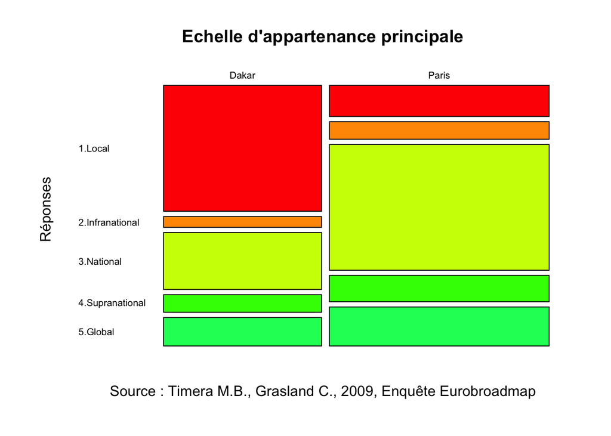

On voit que les niveaux intermédiaires correspondant aux régions d’un pays (infranational) ou aux régions du Monde (supranational) ont été peu mobilisés dans les deux pays. L’appartenance à l’Europe ou l’Afrique ne semble donc pas privilégiée par les étudiants, tout comme celle à des parties du pays (e.g. Bretagne en France ou Casamance au Sénégal). Les niveaux dominants sont le niveau local au Sénégal (53% des réponses) et le niveau national en France (52% des réponses). Quant au niveau global; il représente 12% des réponses au Sénégal et 16% en France. Nous proposons donc dans les analyses suivantes de regrouper les réponqes en trois classes en fusionnant les réponses 1-2 d’une part et 4-5 d’autre part.

### Echelle d’appartenance et sexe

Y-a-t-il des différences significative entre les hommes et les femmes en matière d’échelle d’appartenance dans l’un ou l’autre des deux échantillons.

```
         Inf   Nat   Sup   Total
  Femmes  52.6  28.9  18.4 100.0
  Hommes  58.4  22.6  19.0 100.0
  All     57.1  24.0  18.9 100.0
```

```
         Inf   Nat   Sup   Total
  Femmes  22.1  47.8  30.1 100.0
  Hommes  18.2  58.2  23.6 100.0
  All     20.3  52.4  27.2 100.0
```

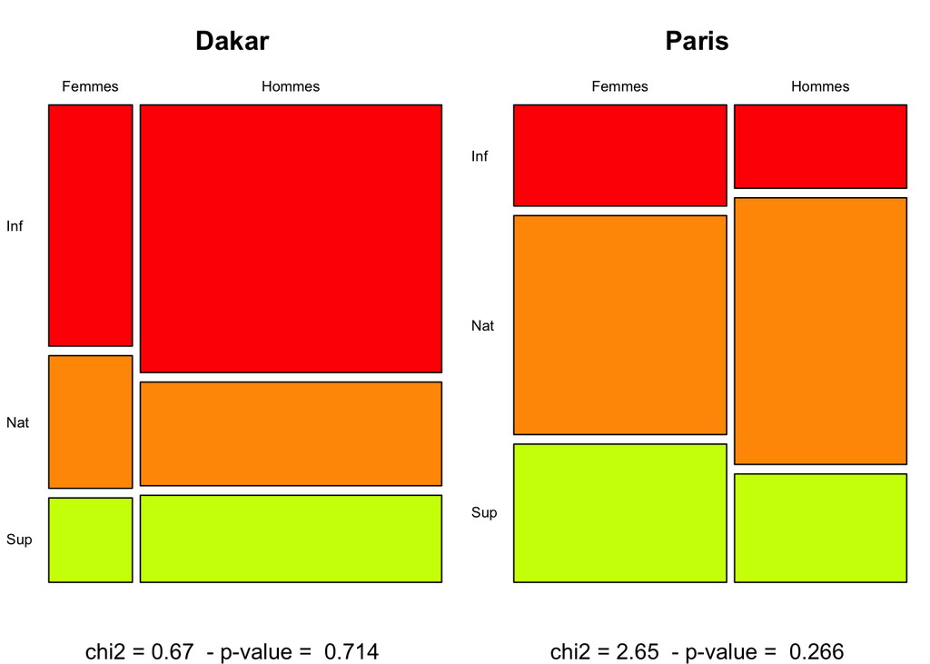

La réponse est négative dans les deux cas. Tout au plus peut-on observer que les hommes déclarent plus fréquemment l’échelle nationale comme niveau privilégiée d’appartenance en France alors que c’est l’inverse au Sénégal. Mais dans les deux cas, l’échantillonne permet pas de conclure à une relation significative.

### Echelle d’appartenance et mobilité internationale

Les étudiants qui ont effectué une mobilité internationale de plus de six mois ont-il des échelles d’appartenance plus globale que ceux qui n’ont jamais séjourné plus de 6 mois dans un pays étranger ?

```
      Inf   Nat   Sup   Total
  Non  59.2  22.4  18.4 100.0
  Oui  44.0  32.0  24.0 100.0
  All  57.1  23.7  19.2 100.0
```

```
      Inf   Nat   Sup   Total
  Non  20.7  53.8  25.5 100.0
  Oui  18.4  44.7  36.8 100.0
  All  20.3  52.4  27.2 100.0
```

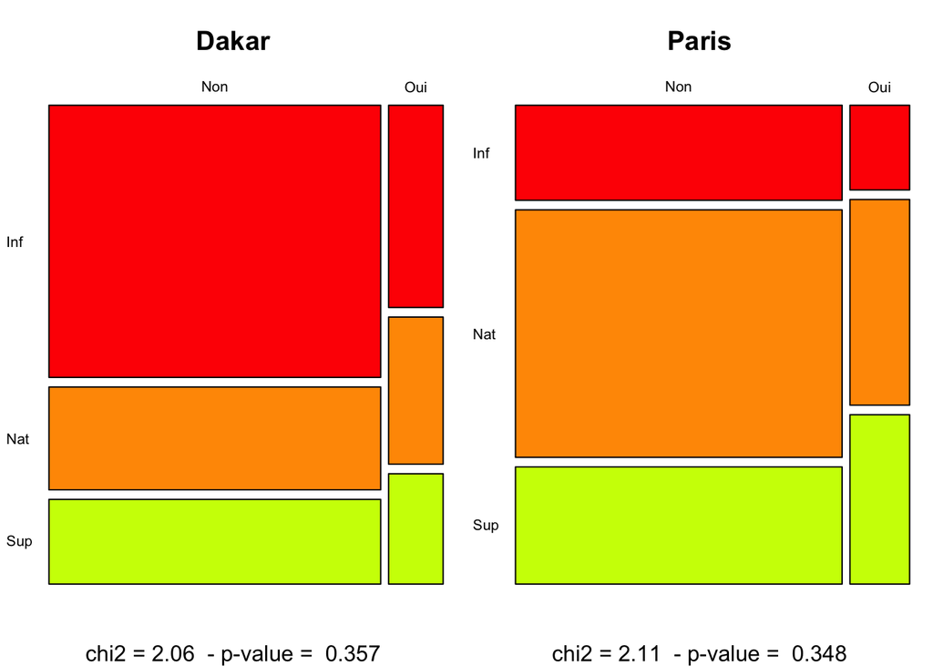

# 2. Pays attractifs et répulsifs

Une manière efficace de mettre à jour les représentations du Monde des étudiants a consisté à leur demander les villes et les pays où ils souhaiteraient vivre ou ne pas vivre dans un futur proche. Ces questions en apparence banales se sont révélées très riches en termes d’interprétation et ont été à l’origine du développement de nombreuses méthodes d’analyse inédites.

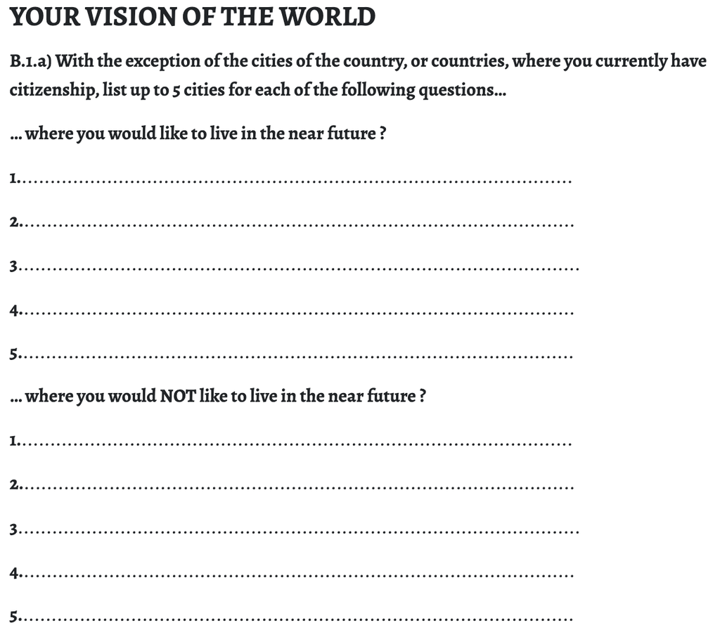

EuroBroadmap 2010, partie 2

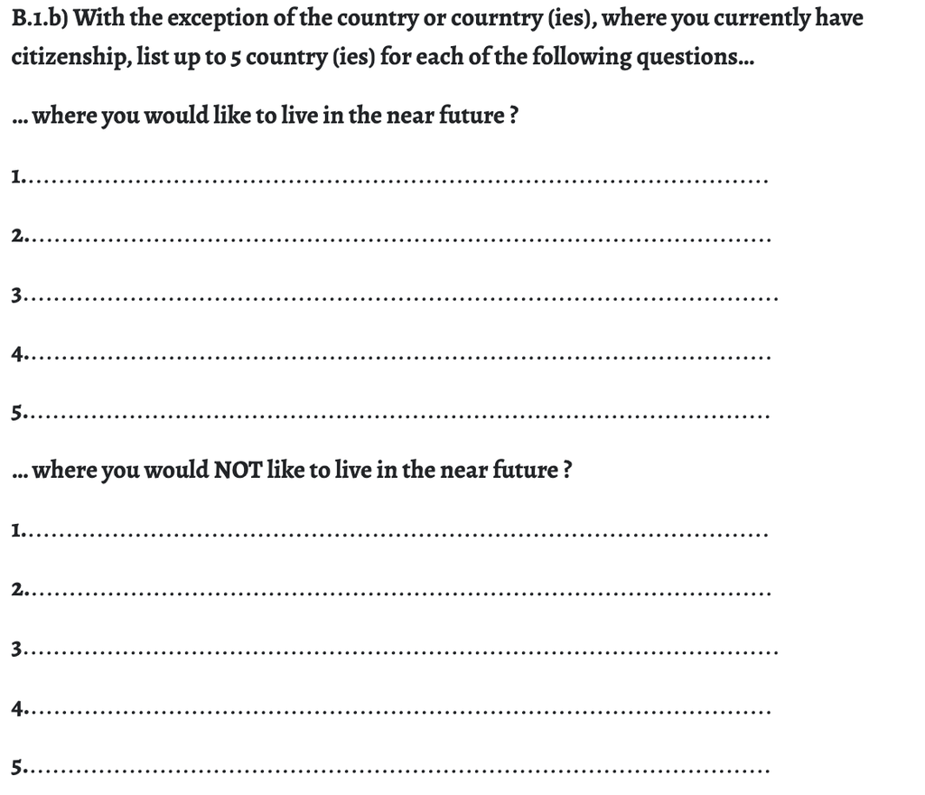

EuroBroadmap 2010, partie 2

Nous n’avons retenu ici que les pays en nous limitant aux 3 premières réponses à chaque question, car beaucoup d’étudiants ont eu des difficultés à en fournir 5, surtout lorsqu’il s’agissait des réponses négatives sur les pays ou villes dans lesquelles ils n’aimeraient pas vivre.

## 2.1 Données

L’exercice proposé ici aux étudiants va les amener à combiner statistique et cartographie. Ils pourront au choix

1. utiliser le logiciel R pour effectuer tous les traitements
2. Utiliser Excel pour les analyse statistiques et Qgis pour les analyses cartographiques

**Télécharger le jeu de données n°2**

- [Données sur les pays cités au format .xlsx](https://github.com/worldregio/altermap/raw/refs/heads/main/data/parisdakar/tabstates.xlsx)
- [Données sur les pays cités au format .RDS](https://github.com/worldregio/altermap/raw/refs/heads/main/data/parisdakar/tabstates.RDS)
- - [Fonds de carte des pays au format .geojson](https://github.com/worldregio/altermap/raw/refs/heads/main/data/parisdakar/mapstates.geojson)
- [Fonds de carte des pays au fomat .RDS](https://github.com/worldregio/altermap/raw/refs/heads/main/data/parisdakar/mapstates.RDS)

### Données statistiques

Le fichier de données *tabstates* comporte autant de ligne qu’il y a eu de réponses valides sur les pays attractifs et répulsifs. Un étudiant qui a donné 6 réponses correspondra donc à six lignes dans le tableau.

Réponses d’un étudiant sénégalais

| id | code | rnk | opi | nom | region | continent |
| --- | --- | --- | --- | --- | --- | --- |
| SEN-DKR-ART-205 | NGA | 1 | pos | Nigeria | Western Africa | Africa |
| SEN-DKR-ART-205 | BFA | 2 | pos | Burkina Faso | Western Africa | Africa |
| SEN-DKR-ART-205 | CAN | 3 | pos | Canada | Northern America | Americas |
| SEN-DKR-ART-205 | FRA | 1 | neg | France | Western Europe | Europe |
| SEN-DKR-ART-205 | ITA | 2 | neg | Italy | Southern Europe | Europe |
| SEN-DKR-ART-205 | ESP | 3 | neg | Spain | Southern Europe | Europe |

### Données géométriques

La cartograhie sera réalisée à l’aide d’un fonds de carte des pays du Monde en 2009 en utilisant le code ISO3 pour effectuer les jointures avec le tableau de données. On pourra également réaliser des cartes par continent ou sous-continent si on le souhaite. On choisira par défaut une projection polaireidentique à celle qui a été utilisée dans l’enquête EuroBroadMap pour découper le monde en régions

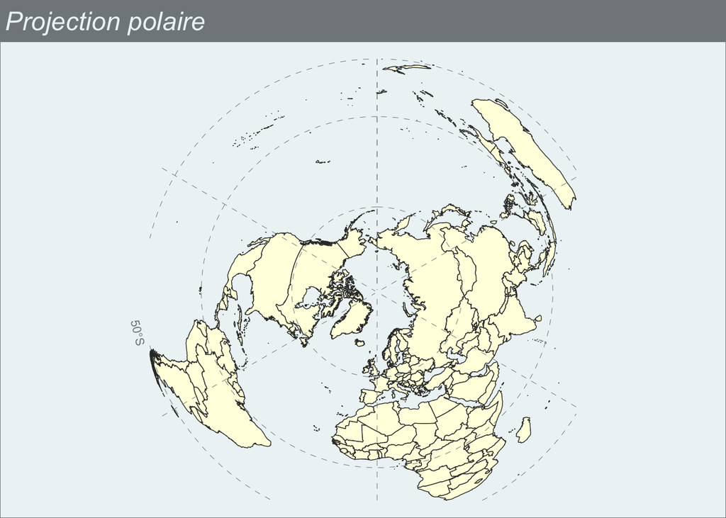

## 2.1 Pays attractifs

### Sénégal

Pays les plus attractifs pour les étudiants sénégalais en 2009

| Rang | Code | Nom | Nb. réponses | % réponses | % étudiants |
| --- | --- | --- | --- | --- | --- |
| 1 | USA | USA | 90 | 16.1 | 46.2 |
| 2 | CAN | Canada | 85 | 15.2 | 43.6 |
| 3 | FRA | France | 76 | 13.6 | 39.0 |
| 4 | GBR | U.K. | 38 | 6.8 | 19.5 |
| 5 | CHE | Switzerland | 30 | 5.4 | 15.4 |
| 6 | SAU | Saudi Arabia | 25 | 4.5 | 12.8 |
| 7 | JPN | Japan | 16 | 2.9 | 8.2 |
| 9 | ITA | Italy | 14 | 2.5 | 7.2 |
| 9 | MAR | Morocco | 14 | 2.5 | 7.2 |
| 9 | ZAF | South Africa | 14 | 2.5 | 7.2 |
| 12 | AUS | Australia | 13 | 2.3 | 6.7 |
| 12 | ESP | Spain | 13 | 2.3 | 6.7 |
| 14 | BEL | Belgium | 11 | 2.0 | 5.6 |
| 14 | MLI | Mali | 11 | 2.0 | 5.6 |
| 15 | CIV | Côte d’Ivoire | 9 | 1.6 | 4.6 |
| 16 | CHN | China | 7 | 1.3 | 3.6 |
| 16 | DEU | Germany | 7 | 1.3 | 3.6 |
| 18 | BRA | Brazil | 6 | 1.1 | 3.1 |
| 18 | GMB | Gambia | 6 | 1.1 | 3.1 |
| 22 | CPV | Cape Verde | 5 | 0.9 | 2.6 |

- **Commentaire** : Les trois pays les plus attractifs pour les étudiants sénégalais interrogés en 2009 à Dakar sont les USA, le Canada et la France, qui sont mentionnés dans leurs trois premiers choix par respectivement 46%, 44% et 39% des étudiants. On trouve ensuite le Royaume-Uni (20%),la Suisse (15%), l’Arabie Saoudite (13%) et nettement plus loin le Japon, l’Italie, le Maroc, l’Afrique du Sud ou l’Australie. La part des pays africains est toutefois moins faible qu’il n’y paraît car plusieurs d’entre eux sont cités surtout s’ils sont situés en Afrique de l’Ouest

Régions du monde les plus attractives pour les étudiants sénégalais en 2009

| Rang | Continent | region | Nb. réponses | % réponses |
| --- | --- | --- | --- | --- |
| 1 | Europe | Western Europe | 191 | 17.1 |
| 2 | Americas | Northern America | 187 | 16.8 |
| 3 | Africa | Western Africa | 140 | 12.6 |
| 4 | Asia | Western Asia | 138 | 12.4 |
| 5 | Asia | Southern Asia | 96 | 8.6 |
| 6 | Europe | Southern Europe | 66 | 5.9 |
| 7 | Africa | Northern Africa | 52 | 4.7 |
| 8 | Europe | Northern Europe | 50 | 4.5 |
| 9 | Africa | Eastern Africa | 45 | 4.0 |
| 10 | Europe | Eastern Europe | 34 | 3.1 |
| 11 | Asia | Eastern Asia | 31 | 2.8 |
| 12 | Africa | Middle Africa | 27 | 2.4 |
| 13 | Africa | Southern Africa | 20 | 1.8 |
| 14 | Oceania | Australia and New Zealand | 16 | 1.4 |
| 15 | Americas | South America | 9 | 0.8 |
| 16 | Asia | South-Eastern Asia | 6 | 0.5 |
| 17 | Americas | Central America | 3 | 0.3 |
| 18 | Americas | Caribbean | 2 | 0.2 |
| 19 | Oceania | Polynesia | 1 | 0.1 |

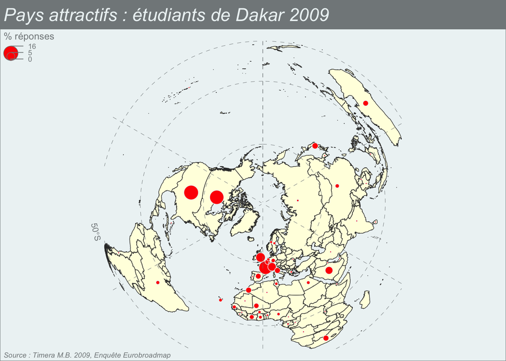

### France

Pays les plus attractifs pour les étudiants français en 2009

| Rang | Code | Nom | Nb. réponses | % réponses | % étudiants |
| --- | --- | --- | --- | --- | --- |
| 1 | USA | USA | 106 | 15.3 | 40.6 |
| 2 | GBR | U.K. | 94 | 13.5 | 36.0 |
| 3 | ESP | Spain | 62 | 8.9 | 23.8 |
| 4 | ITA | Italy | 57 | 8.2 | 21.8 |
| 5 | CAN | Canada | 51 | 7.3 | 19.5 |
| 6 | AUS | Australia | 44 | 6.3 | 16.9 |
| 7 | DEU | Germany | 36 | 5.2 | 13.8 |
| 8 | SWE | Sweden | 21 | 3.0 | 8.0 |
| 9 | JPN | Japan | 18 | 2.6 | 6.9 |
| 10 | IRL | Ireland | 17 | 2.4 | 6.5 |
| 11 | BEL | Belgium | 13 | 1.9 | 5.0 |
| 12 | ARG | Argentina | 12 | 1.7 | 4.6 |
| 12 | CHN | China | 12 | 1.7 | 4.6 |
| 14 | NOR | Norway | 9 | 1.3 | 3.4 |
| 16 | CHE | Switzerland | 8 | 1.2 | 3.1 |
| 16 | NZL | New Zealand | 8 | 1.2 | 3.1 |
| 18 | GRC | Greece | 7 | 1.0 | 2.7 |
| 18 | IND | India | 7 | 1.0 | 2.7 |
| 18 | NLD | Netherlands | 7 | 1.0 | 2.7 |
| 20 | BRA | Brazil | 6 | 0.9 | 2.3 |

- **Commentaire** : Les deux pays les plus attractifs pour les étudiants franaçis interrogés en 2009 à Paris sont les USA et le Royaume-Uni, qui sont mentionnés dans leurs trois premiers choix par respectivement 41% et 36% des étudiants. On trouve ensuite l’Espagne (24%),l’Italie (22%), le Canada (20%), l’Australie (17%) et l’Allemagne (14%). Il existe une très forte concentration des réponses sur les pays occidentaux d’Europe et d’Amérique

Régions du monde les plus attractives pour les étudiants français en 2009

| Rang | Continent | region | Nb. réponses | % réponses |
| --- | --- | --- | --- | --- |
| 1 | Americas | Northern America | 207 | 15.2 |
| 2 | Europe | Northern Europe | 185 | 13.6 |
| 3 | Europe | Southern Europe | 164 | 12.0 |
| 4 | Asia | Eastern Asia | 146 | 10.7 |
| 5 | Asia | Southern Asia | 130 | 9.6 |
| 6 | Europe | Western Europe | 127 | 9.3 |
| 7 | Asia | Western Asia | 118 | 8.7 |
| 8 | Europe | Eastern Europe | 72 | 5.3 |
| 9 | Oceania | Australia and New Zealand | 57 | 4.2 |
| 10 | Americas | South America | 38 | 2.8 |
| 11 | Africa | Northern Africa | 35 | 2.6 |
| 12 | Africa | Western Africa | 18 | 1.3 |
| 13 | Africa | Eastern Africa | 16 | 1.2 |
| 14 | Americas | Central America | 12 | 0.9 |
| 15 | Africa | Southern Africa | 11 | 0.8 |
| 16 | Asia | South-Eastern Asia | 10 | 0.7 |
| 18 | Americas | Caribbean | 6 | 0.4 |
| 18 | Africa | Middle Africa | 6 | 0.4 |
| 19 | Asia | Central Asia | 2 | 0.1 |
| 20 | Oceania | Melanesia | 1 | 0.1 |

- **Commentaire** : Ce qui frappe le plus dans ces réponses est l’absence presque totale de réponses mentionnant une attraction pour les pays d’Afrique et d’Amérique latine.

[figure not shown]

- **Commentaire** : Les étudiants français partagent avec les étudiants sénégalais une attraction pour l’Amérique du Nord et l’Europe de l’Ouest. Mais ils sont également fortement attirés par l’Europe du Sud, l’Australie et certains pays d’Asie orientale. Très peu de pays d’Afrique ont été cités positivement en dehors de l’Afique du Sud (6 étudiants) et du Sénégal (4 étudiants)

## 2.2 Pays répulsifs

Avant d’interpréter les résultats à cette question, il est important de rappeler que les réponses ont été données en 2009 donc avant les printemps arabes et la guerre civile de Syrie mais peu de temps après les crises majeures qui ont touche l’Irak et l’Afghanistan. L’enquête a eu lieu quelques mois après la fin de la guerre de Gazza de 2008-2009 (*opération “plomb durci”*) qui avait fait déjà de nombreuses victimes civiles et suscité une réprobation internationale contre l’action de l’armée israélienne. L’image de la France en Afrique en général et au Sénégal en particulier s’était fortement dégradée suite au discours de N. Sarkozy à Dakar, affirmant que “*L’homme africain n’est pas entré dans l’histoire*”. Inversement, les USA bénéficiaient de l’image positive de Barack Obama élu en novembre 2008.

### Sénégal

Pays les plus répulsifs pour les étudiants sénégalais en 2009

| Rang | Code | Nom | Nb. réponses | % réponses | % étudiants |
| --- | --- | --- | --- | --- | --- |
| 1 | AFG | Afghanistan | 55 | 9.8 | 28.2 |
| 2 | IRQ | Iraq | 50 | 8.9 | 25.6 |
| 3 | FRA | France | 43 | 7.6 | 22.1 |
| 4 | ISR | Israel | 39 | 6.9 | 20.0 |
| 5 | GIN | Guinea | 34 | 6.0 | 17.4 |
| 6 | RUS | Russian Federation | 25 | 4.4 | 12.8 |
| 7 | ITA | Italy | 20 | 3.6 | 10.3 |
| 8 | IRN | Iran | 17 | 3.0 | 8.7 |
| 9 | SOM | Somalia | 16 | 2.8 | 8.2 |
| 10 | SDN | Sudan | 14 | 2.5 | 7.2 |
| 12 | DEU | Germany | 13 | 2.3 | 6.7 |
| 12 | PAK | Pakistan | 13 | 2.3 | 6.7 |
| 13 | USA | USA | 12 | 2.1 | 6.2 |
| 14 | ETH | Ethiopia | 11 | 2.0 | 5.6 |
| 16 | ESP | Spain | 10 | 1.8 | 5.1 |
| 16 | GNB | Guinea-Bissau | 10 | 1.8 | 5.1 |
| 16 | MRT | Mauritania | 10 | 1.8 | 5.1 |
| 18 | COG | Congo | 9 | 1.6 | 4.6 |
| 20 | GMB | Gambia | 8 | 1.4 | 4.1 |
| 20 | IND | India | 8 | 1.4 | 4.1 |

- **Commentaire** : Les deux pays les plus répulsifs pour les étudiants sénégalais interrogés en 2009 à Dakar sont l’Afghanistan (28%) et l’Irak (26%) ce qui s’explique assez simplement par les guerres et les violence qui les touchent au moment de l’enquête. Mais le pays suivants sont la France (22%) et Israël (20%) en raison probablement des effets du discours de Dakar de N. Sarkozy (2007) et de l’opération plomb durci à Gazza en 2008-09. Le conflit qui touche la Guinée voisine est également cité (17%) en raison de la proximité et, probablement, d’une meilleur information que celle qu’on trouve en France où ce pays n’est pratiquement pas mentionné. On trouve ensuite la Russie (13%), l’Italie (10%), l’Iran (9%), etc. Le résultat le plus étonnant est le très faible nombre d’étudiant sénégalais qui citent négativement les USA (6%) ce qui est sans doute lié à l’état de grâce du début de la présidence Obama.

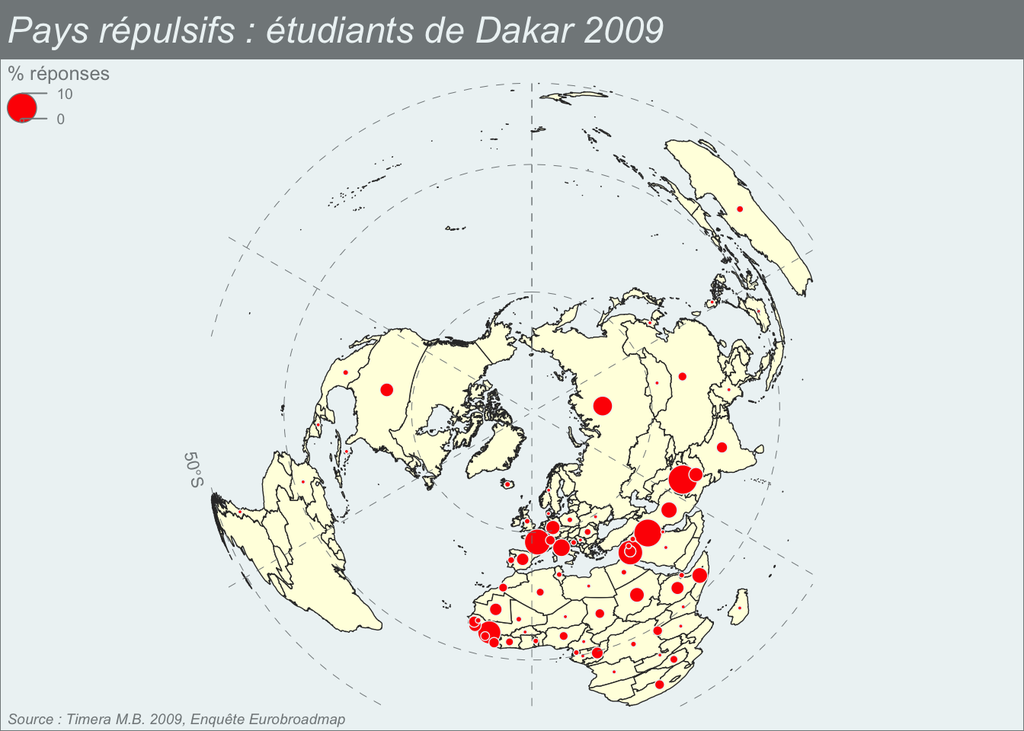

- **Commentaire** : la cartographie des réponses montre une forte dispersion des réponses entre un grand nombre de pays et une couverture remarquable du continent africain dont presque tous les pays sont cités au moins une fois. ce résultat ne doit pas s’interpréter comme un rejet des pays africains mais plutôt comme la preuve d’une bonne information sur ces pays. A contrario, on remarquera que les pays d’Amérique latine ou d’Asie-Pacifique ne sont pour ainsi dire pas cités. La distance joue clairement un rôle dans la conscience que les étudiants ont de l’existence des pays et de l’appréciatin qu’ils portent sur eux, positivement ou négativement. Nos y reviendrons dans la partie de synthèse.

### France

Pays les plus répulsifs pour les étudiants français en 2009

| Rang | Code | Nom | Nb. réponses | % réponses | % étudiants |
| --- | --- | --- | --- | --- | --- |
| 1 | CHN | China | 70 | 10.4 | 26.8 |
| 2 | IRQ | Iraq | 50 | 7.4 | 19.2 |
| 3 | RUS | Russian Federation | 49 | 7.2 | 18.8 |
| 4 | IRN | Iran | 42 | 6.2 | 16.1 |
| 4 | USA | USA | 42 | 6.2 | 16.1 |
| 6 | AFG | Afghanistan | 40 | 5.9 | 15.3 |
| 7 | JPN | Japan | 31 | 4.6 | 11.9 |
| 8 | DEU | Germany | 27 | 4.0 | 10.3 |
| 9 | IND | India | 20 | 3.0 | 7.7 |
| 10 | GBR | U.K. | 18 | 2.7 | 6.9 |
| 11 | PAK | Pakistan | 14 | 2.1 | 5.4 |
| 12 | ISR | Israel | 13 | 1.9 | 5.0 |
| 14 | DZA | Algeria | 12 | 1.8 | 4.6 |
| 14 | ESP | Spain | 12 | 1.8 | 4.6 |
| 16 | CHE | Switzerland | 11 | 1.6 | 4.2 |
| 16 | SAU | Saudi Arabia | 11 | 1.6 | 4.2 |
| 18 | ITA | Italy | 10 | 1.5 | 3.8 |
| 18 | MEX | Mexico | 10 | 1.5 | 3.8 |
| 20 | PRK | North Korea | 9 | 1.3 | 3.4 |
| 20 | TUR | Turkey | 9 | 1.3 | 3.4 |

- **Commentaire** : Le pays le plus répulsif pour les étudiants interrogés à Paris en 2009 est la Chine (27%), suivie de l’Irak (19%), la Russie (19%), l’Iran (16%), les USA (16%) et l’Afghanistan (15%), suivi par le Japon (12%) et l’Allemagne (10%). On retrouve donc bien comme au Sénégal les pays en crise et en guerre Iirak, Afghanistan), mais la liste est pour le reste à bien des égards différente. Les grandes puissances mondiales font l’objet d’un rejet particulier (Chine, Russie, USA, Japon, Inde) et les pays voisins ne sont pas épargnés (Allemagne, Royaume-Uni). Mais on ne trouve guère de pays pauvres ou éloignés, ceux-ci étant tout simplement ignorés.

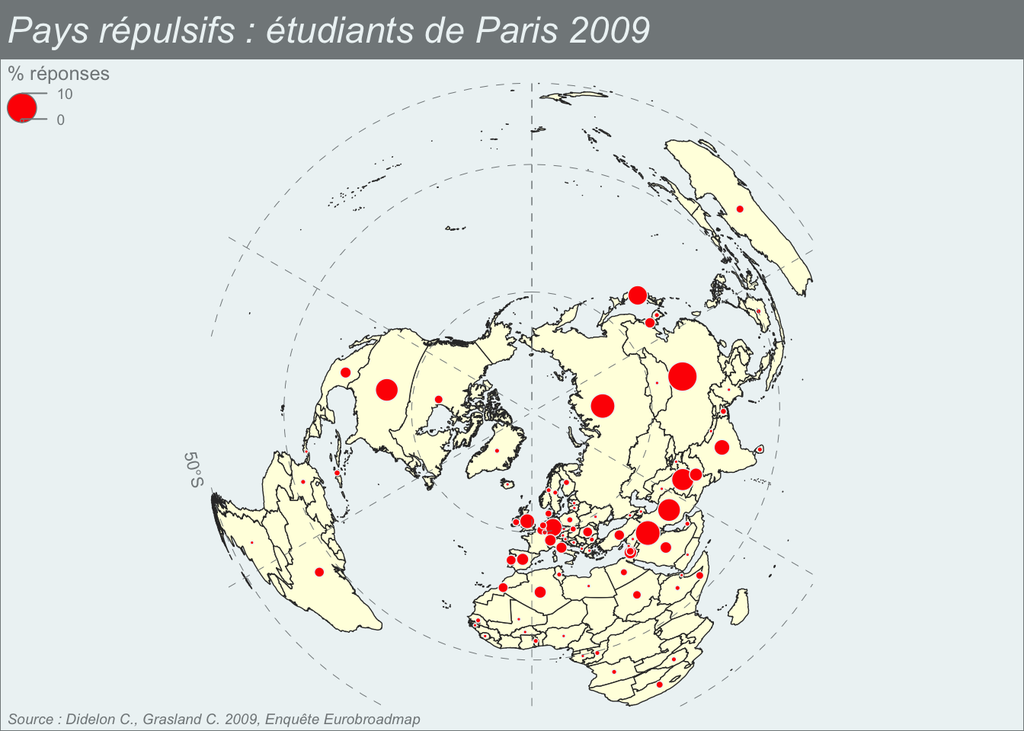

- **Commentaire** : Les étudiants français partagent concentrent leurs opinions négatives sur l’hémisphère Nord et ne mentionnent pratiquement aucun pays au sud de l’équateur. A l’inverse des étudiants sénégalais, ils ne citent pratiquement aucun pays africian en dehors des pays du Maghreb et de ceux de la Corne de l’Afrique. On retrouve donc l’effet de la distance et de l’ignorance déjà noté à propos des étudiants sénégalais. Suggérant l’hypothèse que les pays dont on parle, même négativement, sont des pays auxquels on s’intéresse. Alors que les pays dont on ne parle pas sont ceux qui nous indiffèrent et, à la limite, n’existe pas dans nos représentations. Aucun étudiant parisien n’a cité la Guinée …

## 2.3 Synthèse

### Saillance et polarisation

Ce que montre bien les analyses précédentes est le fait que l’appréciation que les étudiants donnent d’un pays doit être envisagé selon deux dimensions complémentaires, la saillance et l’opinion

- **la saillance** (en anglais *salience*) est le fait qu’un pays se présente à l’esprit dun étudiant lorsqu’on lui demande de porter un jugement. Peu importe que le jugement soit positif ou négatif, si un pays est cité par l’étudiant c’est qu’il possède des informations sur lui, qu’il en a reçu et à choisi de les retenir. Bref, la saillance manifeste une reconnaissance de l’exsitence d’un pays et signale sa présence dans la carte mentale de la personne. On la définira donc comme le % des étudiants qui ont cité un pays positivement ou négativement et on la mesurera sur une échelle de 0 à 100

$Saillance_i = 100\times \frac{Pos_i + Neg_i}{n}$

$Polarisation_i = \frac{Pos_i-Neg_i}{Pos_i+Neg_i}$

### Sénégal

On ne retient que les pays ayant été cités par au moins 10 étudiants sénégalais pour calculer les indicateurs de saillance et de polarisation.

Synthèse des perceptions des pays du monde des étudiants sénégalais en 2009

| Code | Nom | Négatif | Positif | Total | Saillance (%) | Polarisation |
| --- | --- | --- | --- | --- | --- | --- |
| FRA | France | 43 | 76 | 119 | 61.0 | 0.28 |
| USA | USA | 12 | 90 | 102 | 52.3 | 0.76 |
| CAN | Canada | 0 | 85 | 85 | 43.6 | 1.00 |
| AFG | Afghanistan | 55 | 0 | 55 | 28.2 | -1.00 |
| IRQ | Iraq | 50 | 0 | 50 | 25.6 | -1.00 |
| GBR | U.K. | 2 | 38 | 40 | 20.5 | 0.90 |
| ISR | Israel | 39 | 0 | 39 | 20.0 | -1.00 |
| CHE | Switzerland | 6 | 30 | 36 | 18.5 | 0.67 |
| GIN | Guinea | 34 | 1 | 35 | 17.9 | -0.94 |
| ITA | Italy | 20 | 14 | 34 | 17.4 | -0.18 |
| RUS | Russian Federation | 25 | 2 | 27 | 13.8 | -0.85 |
| SAU | Saudi Arabia | 1 | 25 | 26 | 13.3 | 0.92 |
| ESP | Spain | 10 | 13 | 23 | 11.8 | 0.13 |
| DEU | Germany | 13 | 7 | 20 | 10.3 | -0.30 |
| ZAF | South Africa | 6 | 14 | 20 | 10.3 | 0.40 |
| MAR | Morocco | 5 | 14 | 19 | 9.7 | 0.47 |
| IRN | Iran | 17 | 1 | 18 | 9.2 | -0.89 |
| AUS | Australia | 3 | 13 | 16 | 8.2 | 0.62 |
| JPN | Japan | 0 | 16 | 16 | 8.2 | 1.00 |
| SOM | Somalia | 16 | 0 | 16 | 8.2 | -1.00 |
| GMB | Gambia | 8 | 6 | 14 | 7.2 | -0.14 |
| SDN | Sudan | 14 | 0 | 14 | 7.2 | -1.00 |
| CIV | Côte d’Ivoire | 4 | 9 | 13 | 6.7 | 0.38 |
| MLI | Mali | 2 | 11 | 13 | 6.7 | 0.69 |
| PAK | Pakistan | 13 | 0 | 13 | 6.7 | -1.00 |
| CHN | China | 5 | 7 | 12 | 6.2 | 0.17 |
| BEL | Belgium | 0 | 11 | 11 | 5.6 | 1.00 |
| ETH | Ethiopia | 11 | 0 | 11 | 5.6 | -1.00 |
| MRT | Mauritania | 10 | 1 | 11 | 5.6 | -0.82 |
| COG | Congo | 9 | 1 | 10 | 5.1 | -0.80 |
| GNB | Guinea-Bissau | 10 | 0 | 10 | 5.1 | -1.00 |

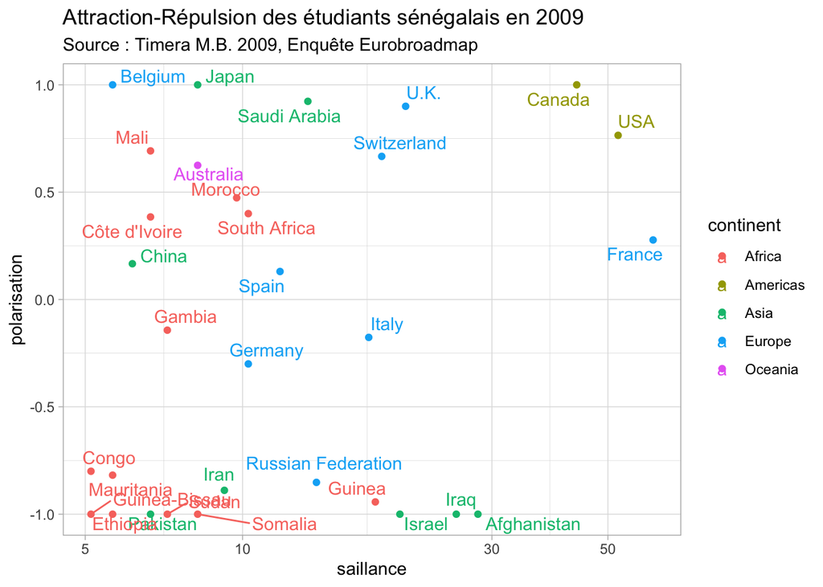

- **Commentaire** : Ce graphique permet de mieux saisir la position des pays en fonction des deux paramères de saillance et de polarisation. Les pays situés à droite sont ceux qui sont le plus cités, les pays à gauche les moins cités. Les pays situés en haut sont les plus atractifs, les pats situés en pas sont les moins attractifs. On peut alors opérer des regroupements entre des pays yant des coordonnées proches comme les USA et le Canada (très forte saillance et attraction) ou l’Israël, l’Irak et l’Afghanisan( forte saillance et forte répulsion). On note que les pays africains (en rouge) se caractérisent généralement par une saillance moyenne à faible, mais avec des niveaux de polarisation très variables, des plus attractifs (Mali, Maroc, Côte d’Ivoire, Afrique du Sud) aux moins attractifs (Guinée, Mauritanie, Congo, …). Les pays ayant des polarisations proches de 0 sont ceux qui méritent une analyse plus précise à partir des autres variables de cadrage puisqu’ils suscitent un nombre équivalent d’avis positif et négatifs. C’est le cas de la France, mais aussi de l’Espagne, la Chine la Gambie, l’Allemagne ou l’Italie.

### France

On ne retient que les pays ayant été cités par au moins 10 étudiants français pour calculer les indicateurs de saillance et de polarisation.

Synthèse des perceptions des pays du monde des étudiants français en 2009

[output not shown]

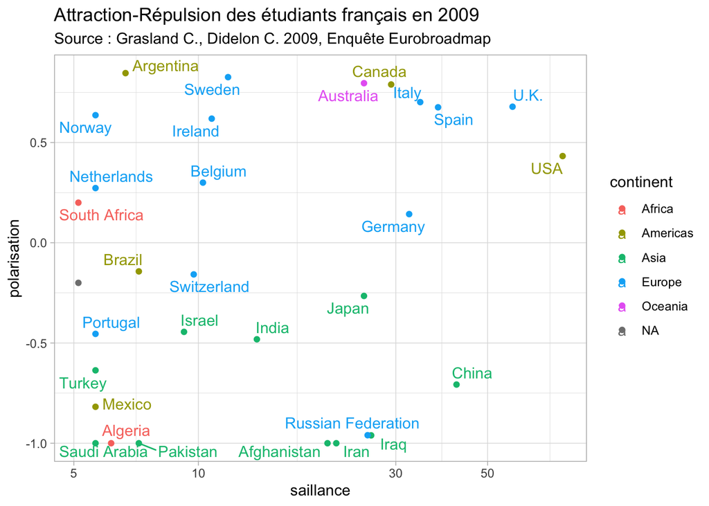